# Models for the Human Sex Ratio

## A function for all family sizes

### Function

Put the previous code into a function to make it easier to replicate for different family sizes.

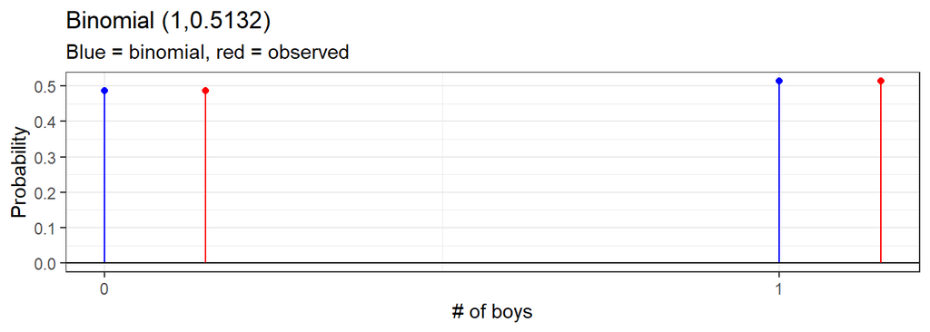

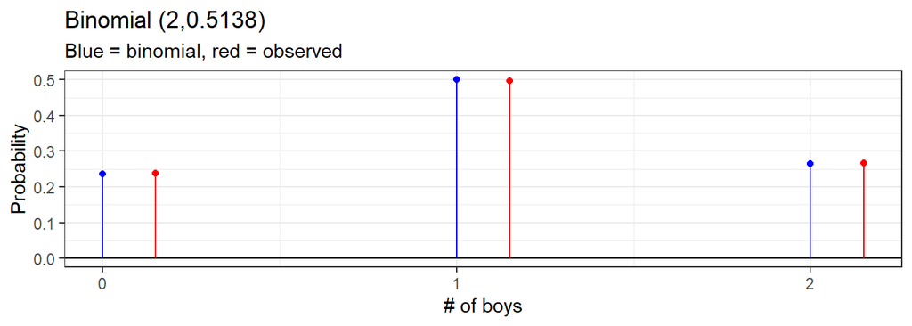

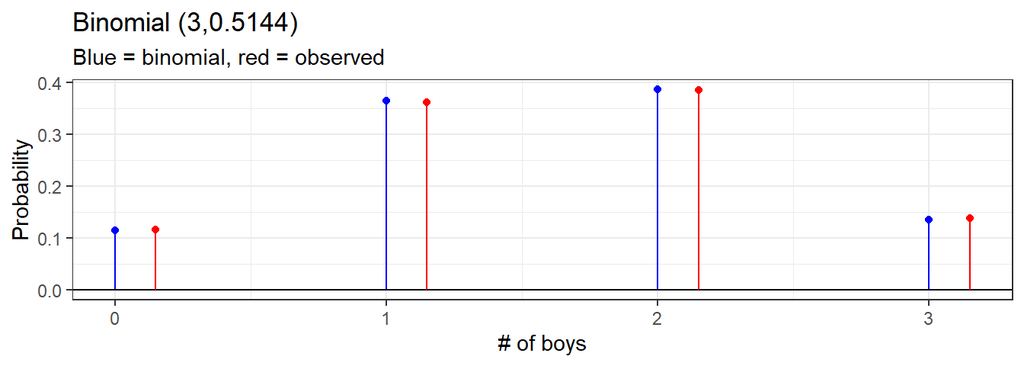

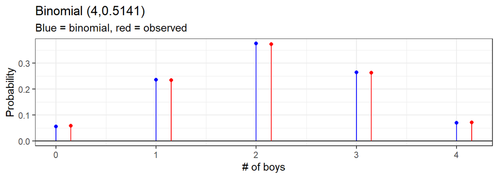

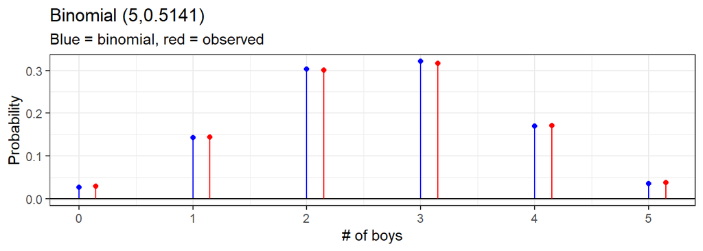

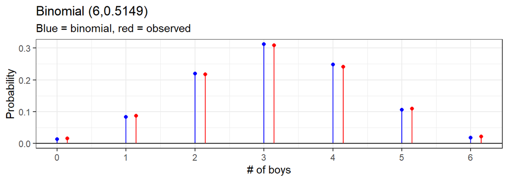

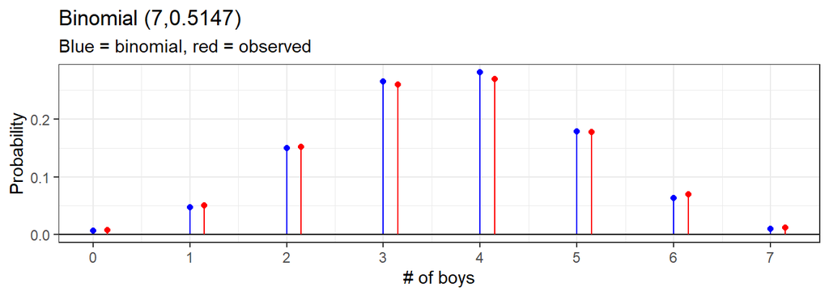

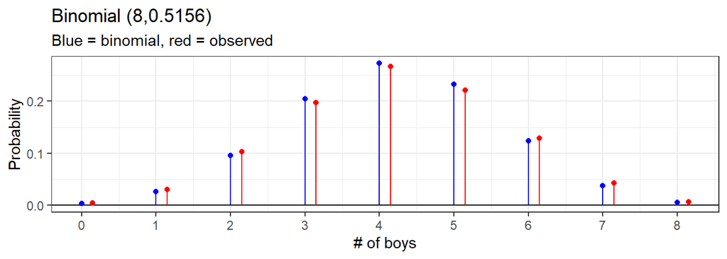

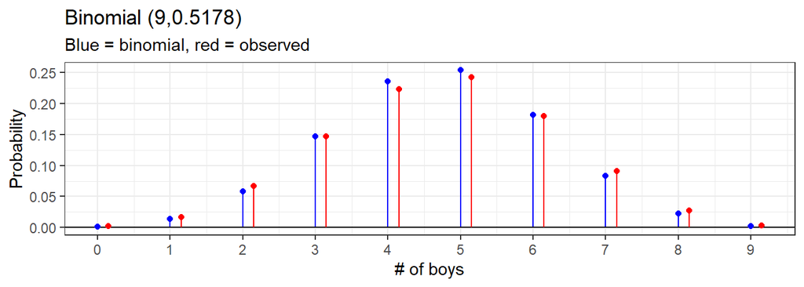

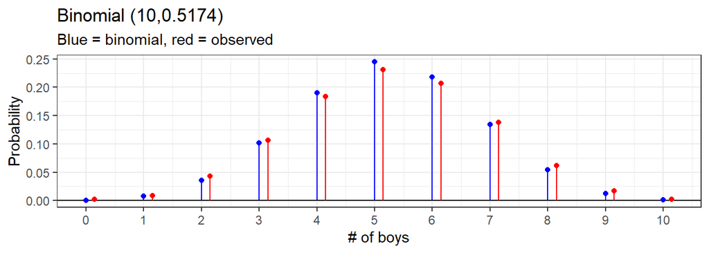

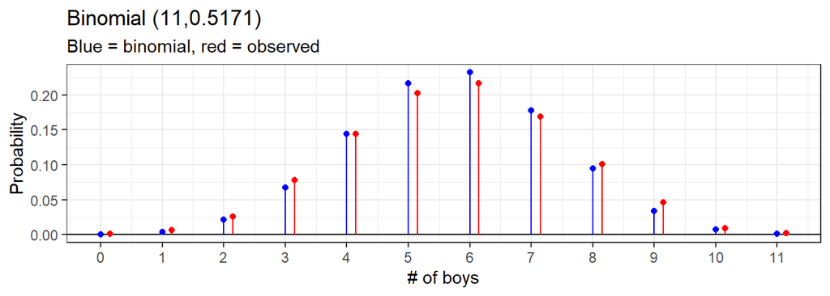

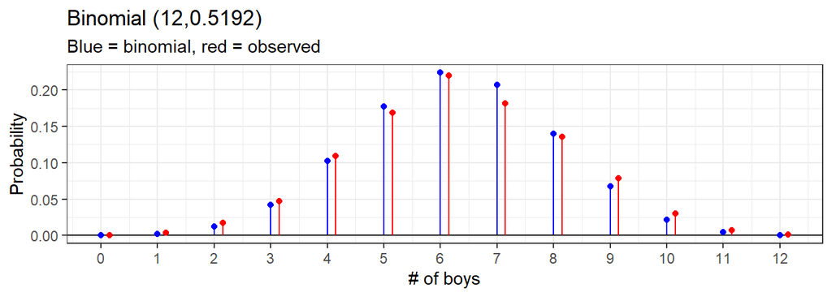

```r
## x is the geissler data (columns boys, girls, size, freq)
## s is the size we filter on
binom_fit_plot = function(x,s)
{
  x = x %>%
    filter(size==s) %>%
    mutate(prop = freq/sum(freq))

  x_sum = x %>%
  summarize(
    boys = sum(boys*freq),
    girls = sum(girls*freq),
    total = sum(size*freq),
    p_boy = boys/total,
    p_girl = girls/total
  )

  x = x %>%
    mutate(p_binom = dbinom(0:s,s,x_sum$p_boy))

  p_boy = x_sum$p_boy
  shift = 0.15
  g = gbinom(s, round(p_boy, 4)) +
    geom_point(aes(x=boys, y=x$p_binom), data=x, color="blue",shape=16) +
    geom_point(aes(x=boys +shift, y=x$prop), data=x, color="red",shape=16) +
    geom_segment(aes(x = boys + shift, y = prop,
                   xend = boys + shift, yend = 0),
               data = x, color = "red") +
    ggtitle(paste0("Binomial (", s, ",", round(p_boy,4), ")"),
            subtitle = "Blue = binomial, red = observed") +
    xlab("# of boys") +
    scale_x_continuous(breaks=0:s) +
    theme_bw()
  return ( g )
}

for ( s in 1:12 )
  plot( binom_fit_plot(geissler,s) )
```

### A Randomization Test

> Can the apparent overdispersion be explained by chance?

Test logic:

1. For a fixed family size (say 8), calculate the sum of absolute differences between observed frequencies and the binomial estimated probabilities.
2. Generate a random sample of the same number of families assuming the binomial model is true.
3. Estimate the binomial probabilities from the data.
4. Calculate the test statistic
5. Compare the test statistic from the real data to the sampling distribution of the test statistic.
6. Draw a conclusion.

```r
## x is a vector of counts from 0 to size
##   with the number of families with that many boys
get_rstat = function(x)
{
  n = length(x) - 1
  boys = 0:n
  observed_p = x/sum(x)
  est_p = sum(boys*x) / sum(n*x)
  binom_p = dbinom(boys,n,est_p)
  return ( sum(abs(observed_p - binom_p)) )
}
```

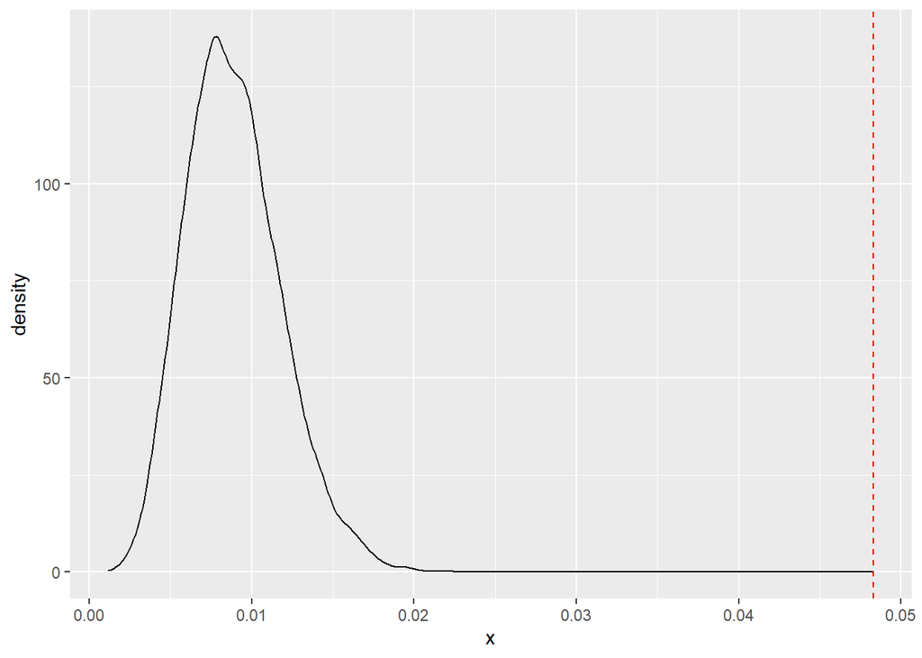

```r
x_8 = geissler %>%
  filter(size==8) %>%
  pull(freq)
p_8 = sum(0:8*x_8) / sum(8*x_8)
families_8 = sum(x_8)

B = 10000
test_8 = numeric(B)

for ( i in 1:B )
{
  boys = rbinom(families_8,8,p_8)
  x = tabulate(boys+1,9)
  test_8[i] = get_rstat(x)
}

df8 = tibble(x=test_8)

ggplot(df8, aes(x=x)) +
  geom_density() +
  geom_vline(xintercept = get_rstat(x_8),
             color="red", linetype="dashed")
```

## Family Size 6 Example

```r
size6 = geissler %>%
  filter(size==6) %>%
  mutate(prop = freq/sum(freq))

size6_sum = size6 %>%
  summarize(
    families = sum(freq),
    boys = sum(boys*freq),
    girls = sum(girls*freq),
    total = sum(size*freq),
    p_boy = boys/total,
    p_girl = girls/total
  )

size6_sum
```

```
## # A tibble: 1 x 6
##   families   boys  girls  total p_boy p_girl
##      <dbl>  <dbl>  <dbl>  <dbl> <dbl>  <dbl>
## 1    72069 222638 209776 432414 0.515  0.485
```

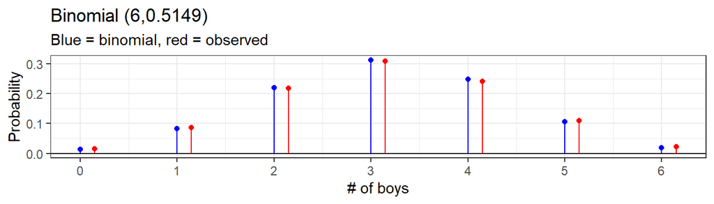

```r
p_6 = size6_sum$p_boy

size6 = size6 %>%
  mutate(p_binom = dbinom(0:6,6,p_6))

binom_fit_plot(geissler,6)
```

### Three Models

#### Binomial Model

$$X_i \,\mid\,p \sim \text{Binomial}(6,p), \quad \text{for all $i$}$$
$$\mathsf{P}(X_i = x) = \binom{n}{x} p^x(1-p)^{n-x},
\quad \text{for $x=0,1,\ldots,n$}$$
where $0<p<1$.

#### Beta-Binomial Model

$$X_i \,\mid\,\alpha,\beta \sim \text{Beta-Binomial}(6,\alpha,\beta),
\quad \text{for all $i$}$$
$$\mathsf{P}(X_i = x) = \binom{n}{x} \frac{B(x+\alpha,n-x+\beta)}{B(\alpha,\beta)},
\quad \text{for $x=0,1,\ldots,n$}$$
where $\alpha>0$ and $\beta>0$.

#### General Independence Model

$$X_i \,\mid\,\mathrm{p} = (p_0,\ldots,p_6) \sim F(\mathrm{p})$$
$$\mathsf{P}(X_i = x) = p_x,
\quad \text{for $x=0,1,\ldots,n$}$$
where $p_x>0$ for all $x$ and $\sum_{x=0^n} p_x = 1$.

### Maximum Likelihood Estimation

Suppose that there are $m_x$ families of size 6 that have $x$ boys.

- The maximum likelihood estimate of $p$ for the **binomial model** is straightforward:
  - Find the total number of boys divided by the total number of children in the families.
    $$\hat{p} = \frac{\sum_{x=0}^6 x m_x}{6\sum_{x=0}^6 m_x}$$
- The maximum likelihood estimate for the **general independence model** is also straightforward:
  - Just calculate the observed proportions.
    $$\hat{p}_x = \frac{m_x}{\sum_{i=0}^6 m_x}$$
- For the beta-binomial model, it is more complicated.

## R code for Beta-Binomial

A code block included in the source file provides these functions:

- `dbb()`: probabilities for the beta-binomial distribution
- `mlebb()`: calculate maximum likelihood estimates from a summary of counts of sample values.

### Estimation

#### Binomial Model

```r
size6 = geissler %>%
  filter(size == 6)
x6 = size6 %>%
  pull(freq)
##
p_hat = sum(x6*(0:6))/(6*sum(x6))
logl_1 = sum(x6*dbinom(0:6,6,p_hat,log=TRUE))
logl_1
```

```
## [1] -118177.5
```

#### Beta-Binomial Model

```r
bb_6 = mlebb(x6)
bb_6
```

```
## # A tibble: 1 x 6
##      mu   phi alpha  beta     logl convergence
##   <dbl> <dbl> <dbl> <dbl>    <dbl>       <int>
## 1 0.515  105.  54.1  51.0 -118131.           0
```

### Likelihood Ratio Tests

$$H_0: \text{binomial model}$$
$$H_a: \text{beta-binomial model}$$

#### test statistic

$$G = -2 \times (\log L_0 - \log L_1)$$

```r
G = -2 * (logl_1 - bb_6$logl)
G
```

```
## [1] 93.70255
```

#### Sampling Distribution

The sampling distribution of the test statistic $G$ is approximately chi-squared with one degree of freedom. In general, for large enough sample sizes, the test statistic from a likelihood ratio test will have an approximate chi-square distribution with degrees of freedom equal to the difference in the number of free parameters between the models for the alternative and null hypotheses.

```r
p_value_1 = 1 - pchisq(G,1)
p_value_1
```

```
## [1] 0
```

## A test versus a general model

$$H_0: \text{binomial model}$$
$$H_a: \text{general independence model}$$

#### General Independent Model

```r
## use observed frequencies as the probabilities
p_hat_2 = x6/sum(x6)
logl_2 = sum(x6*log(p_hat_2))
logl_2
```

```
## [1] -118123
```

#### Test Statistic

$$G = -2 \times (\log L_0 - \log L_1)$$

```r
G2 = -2 * (logl_1 - logl_2)
G2
```

```
## [1] 109.0033
```

#### Sampling Distribution

There are seven probabilities in the general distribtuion, but they add up to one, so there are only six free parameters to estimate. As $6-1=5$, we calculate a p-value by finding the area to the right of 109.0033169 under a chi-square density with 5 degrees of freedom.

```r
p_value_2 = 1 - pchisq(G2,5)
p_value_2
```

```
## [1] 0
```

#### Interpretation

There is very strong evidence ($p<10^{-16}$, $G=109.00$, likelihood ratio test), that the Geissler data for families with six children is better fit by a general probability distribution than the binomial distribution.

## Summary

- The data set contains the gender distributions among the first six children for 72,069 Saxon families with seven or more children.
- The binomial model, the beta-binomial model, and the general independence model each specify a probability distribution for a single family to have from 0 to 6 boys.
- These probabilities are summarized in the following table.

| boys | # families | observed | binomial | beta-binomial | general |
| --- | --- | --- | --- | --- | --- |
| 0 | 1096 | 0.01521 | 0.01304 | 0.01505 | 0.01521 |
| 1 | 6233 | 0.08649 | 0.08301 | 0.08729 | 0.08649 |
| 2 | 15700 | 0.21785 | 0.22025 | 0.21873 | 0.21785 |
| 3 | 22221 | 0.30833 | 0.31167 | 0.30313 | 0.30833 |
| 4 | 17332 | 0.24049 | 0.24809 | 0.24505 | 0.24049 |
| 5 | 7908 | 0.10973 | 0.10532 | 0.10957 | 0.10973 |
| 6 | 1579 | 0.02191 | 0.01863 | 0.02117 | 0.02191 |

The log-likelihood for each model is of the form
$$\ln L = \sum_{x=0}^6 m_x \ln p_x$$
where $m_x$ are the counts of the families with $x$ boys out of 6. A summary of the log-likelihoods for each of the three models follow.

| model | log-likelihood | difference | # parameters |
| --- | --- | --- | --- |
| Binomial | -118177.5 | 0.00000 | 1 |
| Beta-Binomial | -118130.6 | 46.85127 | 2 |
| General | -118123.0 | 54.50166 | 6 |